# Effects of underreporting II

Andrea Brizzi

09/04/2021

We try another underreporting experiment. In this case, I will just make use of Binomial Sampling to produce underreporting. I will not explicitely code for missed generations, even though these may arise naturally.

Again, I will set:
$$y_t \sim \text{Binom}(I_t, \pi).$$

Here, I want to apply the methods “as soon as possible”, according to the guidelines in the WebAppendix. In particular, for each of the “observation” time series, I want to obtain the shortest interval that contains at least 12 observations and is longer than 7 days. This means I will have to find the day of first observation, then if the weekly span contains at least 12 obs: GOOD, otherwise extend this until I reach 12. We can code a function that does exactly that:

```r
find_window <- function(incidence, min_cases = 12, g_interval = 7, missed = 14){

  #cutoff missed days
  incidence <- incidence[-(1:missed),]

  ncols <- dim(incidence)[1]

  # find day of first infection
  start <- min(which(incidence$cases !=0))
  if(start == Inf){
    return(incidence)
  }

  end <- start + g_interval - 1
  #total cases in the window
  window_cases <- sum(incidence$cases[start:end])


  while( window_cases < min_cases & end < ncols ){

    end <- end + 1
    window_cases <- window_cases + incidence$cases[end]

  }

  return(incidence[start:end, ])
}
```

Now that we have the function, we can apply it to each of our scenarios. We will now focus exclusively on populations of large sizes, as we explained what might not be ideal for smaller pops. Let s specify the settings…

```r
sims_SEIR <- readRDS(file.path(data_path, "sims_SEIR"))
names <- names(sims_SEIR)[c(2,4,6,8)]

# generation interval parameters
mean_si <- 6.5
sd_si <- sqrt(3^2 + 3.5^2)

# reporting rate
pi <- 0.15
```

… and then start experimenting:

```r
list_plots <- list()
final_stats <- data.frame(method = as.character(),
                          coverage = as.numeric(),
                          R0 = as.numeric(),
                          CIwidth = as.numeric(),
                          total_sims = as.numeric())

estimated_starts <- data.frame(R0 = as.numeric(),
                               estimate = as.numeric())

for (name in names){

  # show results:
  trueR0 <- as.numeric(stringr::str_match(name, "R0=\\s*(.*?)\\s*pop")[2])

  # Transform the data
  df <- as.data.frame(sims_SEIR[[name]])
  df$day <- 1:(dim(df)[1])

  results <- data.frame(sim = as.numeric(),
                        method = as.character(),
                        R0 = as.numeric(),
                        lowR0 = as.numeric(),
                        upR0 = as.numeric())




  # For every possible simulation
  for(c in 1:(ncol(df) - 1)){

    # analyse only if there are decent numbers of cases
    if (sum(df[,c]) > sqrt(1e+06)){

      # Get incidence
      incidence <- data.frame(cases = df[,c])
      incidence$cases <- rbinom(n = length(incidence$cases),
                                size = incidence$cases,
                                prob = pi)
      incidence$day <- 1:dim(incidence)[1]
      incidence <- find_window(incidence)


      #== simple EpiEstim: unique window
      epestim <- epiestim(incidence, mean_GT = mean_si, sd_GT = sd_si)

      results <- rbind(results, data.frame(
        sim = c, method = 'simpleEpiEstim', R0 = epestim[1],
        lowR0 = epestim[2], upR0 = epestim[3]
      ))


      #== Linear Exponential Growth
      if(any(incidence$cases==0)){
        incidence$casesC <- incidence$cases+0.5
        incidence$logcases <- log(incidence$casesC)
      }else{
        incidence$logcases <- log(incidence$cases)
      }


      eglin <- EG_Lin(data = incidence, mean_GT = mean_si, sd_GT = sd_si)

      results <- rbind(results, data.frame(
        sim = c, method = 'EgLin', R0 = eglin[1],
        lowR0 = eglin[2], upR0 = eglin[3]
      ))



      #== EpiEstim with corrections

      ## Only Megan's
      epestim2 <- epiestim_andrea(data = incidence, mean_GT = mean_si, sd_GT = sd_si,
                                  andrea = FALSE, window_length = dim(incidence)[1])

      tmp <- data.frame(R0 = trueR0,
                        estimate = epestim2$estimated_start)
      estimated_starts <- rbind(estimated_starts, tmp)

      epestim2 <- epestim2$results
      results <- rbind(results, data.frame(
          sim = c, method = 'EpiEstim_Megan', R0 = epestim2[1],
          lowR0 = epestim2[2], upR0 = epestim2[3]
      ))

      ## Mine as well
      epestim2 <- epiestim_andrea(data = incidence, mean_GT = mean_si, sd_GT = sd_si,
                                  andrea = TRUE, window_length = dim(incidence)[1])

      epestim2 <- epestim2$results
      results <- rbind(results, data.frame(
          sim = c, method = 'EpiEstim_Andrea', R0 = epestim2[1],
          lowR0 = epestim2[2], upR0 = epestim2[3]
      ))


    }

  }



  rownames(results) <- c()



  results$method <- as.factor(results$method)
  results <- results %>% group_by(method)

  # This is stupid but otherwise I can t get it to work:
  if(trueR0 == 1.5){
    gg <- ggplot(data = results, aes(y = R0, x = method)) + geom_boxplot() +
    geom_hline(aes(yintercept = 1.5),col = "red", linetype = "dashed") + ggtitle(name)
  }
  if(trueR0 == 2){
    gg <- ggplot(data = results, aes(y = R0, x = method)) + geom_boxplot() +
    geom_hline(aes(yintercept = 2),col = "red", linetype = "dashed") + ggtitle(name)
  }
  if(trueR0 == 2.5){
    gg <- ggplot(data = results, aes(y = R0, x = method)) + geom_boxplot() +
    geom_hline(aes(yintercept = 2.5),col = "red", linetype = "dashed") + ggtitle(name)
  }
    if(trueR0 == 3){
    gg <- ggplot(data = results, aes(y = R0, x = method)) + geom_boxplot() +
    geom_hline(aes(yintercept = 3),col = "red", linetype = "dashed") + ggtitle(name)
  }


  list_plots[[name]] <- gg

  results$inside <- (trueR0 <= results$upR0 & trueR0 >= results$lowR0)
  results$CIwidth <- results$upR0 - results$lowR0

  total_sims <- length(unique(results$sim))

  tmp <- results %>% group_by(method) %>%
    summarise(coverage = mean(inside), R0 = trueR0,
              CIwidth = mean(CIwidth), total_sims = total_sims)

  tmp$coverage <- round(tmp$coverage, 2)

  final_stats <- rbind(final_stats, tmp)
}
```

[output not shown]

```r
knitr::kable(final_stats)
```

| method | coverage | R0 | CIwidth | total_sims |
| --- | --- | --- | --- | --- |
| EgLin | 0.71 | 1.5 | 1.438705 | 80 |
| EpiEstim_Andrea | 0.75 | 1.5 | 1.193726 | 80 |
| EpiEstim_Megan | 0.90 | 1.5 | 2.143775 | 80 |
| simpleEpiEstim | 0.90 | 1.5 | 2.233069 | 80 |
| EgLin | 0.90 | 2.0 | 4.107851 | 99 |
| EpiEstim_Andrea | 0.69 | 2.0 | 1.736112 | 99 |
| EpiEstim_Megan | 0.78 | 2.0 | 3.105283 | 99 |
| simpleEpiEstim | 0.67 | 2.0 | 3.427452 | 99 |
| EgLin | 0.94 | 2.5 | 4.937210 | 100 |
| EpiEstim_Andrea | 0.64 | 2.5 | 1.635056 | 100 |
| EpiEstim_Megan | 0.63 | 2.5 | 2.195520 | 100 |
| simpleEpiEstim | 0.40 | 2.5 | 3.029757 | 100 |
| EgLin | 0.95 | 3.0 | 4.141368 | 100 |
| EpiEstim_Andrea | 0.63 | 3.0 | 1.474779 | 100 |
| EpiEstim_Megan | 0.62 | 3.0 | 1.674015 | 100 |
| simpleEpiEstim | 0.16 | 3.0 | 2.440113 | 100 |

```
## $`R0=1.5pop=1e+06`
```

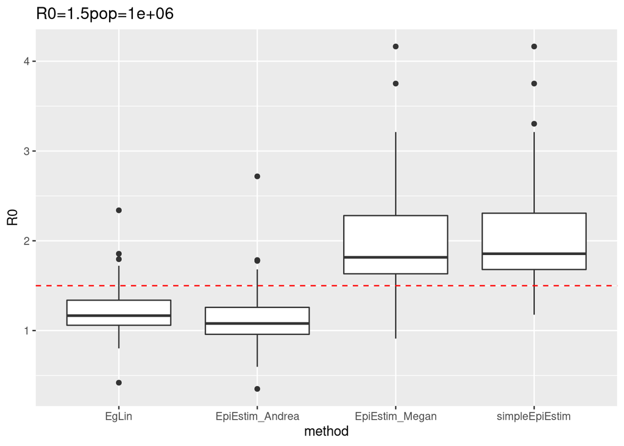

```
##
## $`R0=2pop=1e+06`
```

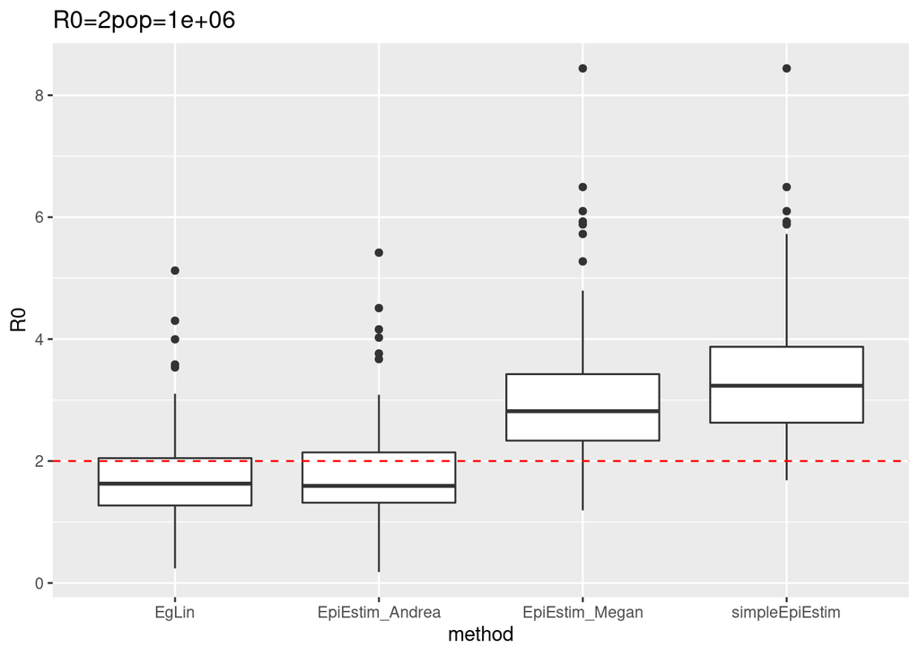

```
##
## $`R0=2.5pop=1e+06`
```

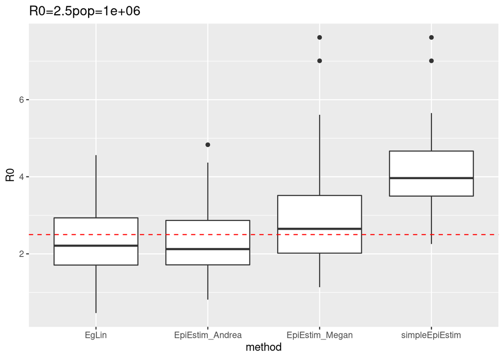

```
##
## $`R0=3pop=1e+06`
```

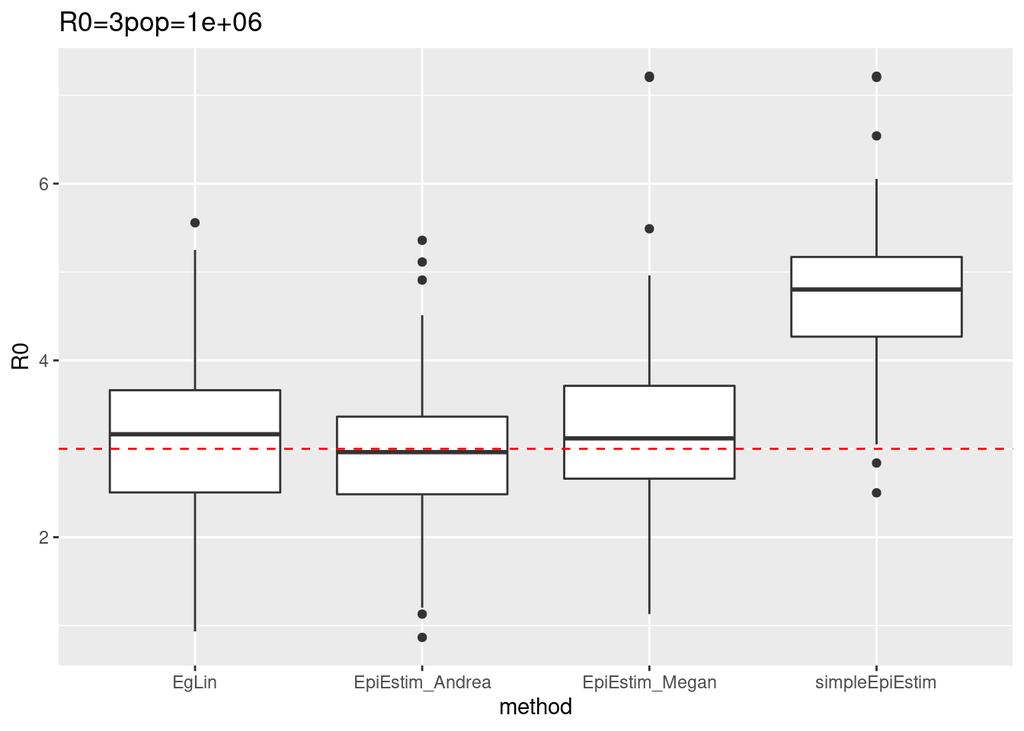

```r
list_plots
```